# Lab 10 - Decision tree

Kyunghee Lee

Below is the code we use from the lecture, plus some exercise questions. The RMD file is on `Code` tab on the top. You can either `Knit` the entire document to produce a html doc, `Run All` to only run R codes, or run one R chunk at a time by clicking the play button. Remember that your code must be inside **R chunks**. Otherwise, your computer would just treat your code as plain text and won’t run it. If you’re not sure what you should do, please refer to the instructions and video in Lab 1.

There is a couple of exercises you can play with. For each question, I put a R chunk and a line saying `# write your code below this comment line` in case you don’t know where to start. You’re welcome to create as many R chunks and do experiments as you like.

# Prerequisite

This lab uses, as always, `tidyverse` package along with `broom` and `caret` we used for the last lab. And there are some new packages to install, whichare `openintro` for the email dataset, and `caTools` for the `colAUC()` function. To install the new packages, use `install.packages()`.

```r
library(tidyverse)
library(openintro)
library(caret)
```

# Building spam filter

```r
str(email)
```

```
## tibble [3,921 × 21] (S3: tbl_df/tbl/data.frame)
##  $ spam        : Factor w/ 2 levels "NS","S": 1 1 1 1 1 1 1 1 1 1 ...
##  $ to_multiple : num [1:3921] 0 0 0 0 0 0 1 1 0 0 ...
##  $ from        : num [1:3921] 1 1 1 1 1 1 1 1 1 1 ...
##  $ cc          : int [1:3921] 0 0 0 0 0 0 0 1 0 0 ...
##  $ sent_email  : num [1:3921] 0 0 0 0 0 0 1 1 0 0 ...
##  $ time        : POSIXct[1:3921], format: "2012-01-01 01:16:41" "2012-01-01 02:03:59" ...
##  $ image       : num [1:3921] 0 0 0 0 0 0 0 1 0 0 ...
##  $ attach      : num [1:3921] 0 0 0 0 0 0 0 1 0 0 ...
##  $ dollar      : num [1:3921] 0 0 4 0 0 0 0 0 0 0 ...
##  $ winner      : Factor w/ 2 levels "no","yes": 1 1 1 1 1 1 1 1 1 1 ...
##  $ inherit     : num [1:3921] 0 0 1 0 0 0 0 0 0 0 ...
##  $ viagra      : num [1:3921] 0 0 0 0 0 0 0 0 0 0 ...
##  $ password    : num [1:3921] 0 0 0 0 2 2 0 0 0 0 ...
##  $ num_char    : num [1:3921] 11.37 10.5 7.77 13.26 1.23 ...
##  $ line_breaks : int [1:3921] 202 202 192 255 29 25 193 237 69 68 ...
##  $ format      : num [1:3921] 1 1 1 1 0 0 1 1 0 1 ...
##  $ re_subj     : Factor w/ 2 levels "0","1": 1 1 1 1 1 1 1 1 1 1 ...
##  $ exclaim_subj: num [1:3921] 0 0 0 0 0 0 0 0 0 0 ...
##  $ urgent_subj : num [1:3921] 0 0 0 0 0 0 0 0 0 0 ...
##  $ exclaim_mess: num [1:3921] 0 1 6 48 1 1 1 18 1 0 ...
##  $ number      : Factor w/ 3 levels "none","small",..: 3 2 2 2 1 1 3 2 2 2 ...
```

## Getting used to `train()`

`train()` is very powerful as it gives us a consistent framework for data analytics. We can use most of the statisticsl techniques available out there just a matter of replacing a few arguments in the function. It’s definately worth your time getting used to as you might not need anything else when it comes to predictive modeling.

Let’s use recap the previous lecture where we build a logistic model using `glm()`.

```r
glm(spam ~ num_char,
  data = email,
  family = "binomial"
)
```

```
##
## Call:  glm(formula = spam ~ num_char, family = "binomial", data = email)
##
## Coefficients:
## (Intercept)     num_char
##    -1.79874     -0.06207
##
## Degrees of Freedom: 3920 Total (i.e. Null);  3919 Residual
## Null Deviance:       2437
## Residual Deviance: 2346  AIC: 2350
```

Using `train()` to build a logistic model is as simple as switching `method`.

```r
spam_caret <- train(
  spam ~ num_char,
  data = email,
  method = "glm"
)
spam_caret$finalModel
```

```
##
## Call:  NULL
##
## Coefficients:
## (Intercept)     num_char
##    -1.79874     -0.06207
##
## Degrees of Freedom: 3920 Total (i.e. Null);  3919 Residual
## Null Deviance:       2437
## Residual Deviance: 2346  AIC: 2350
```

The two models show exactly the same output. Plus, `train()` does way more than what `glm()` is capable of!

Let’s do the 10-fold cross validation using `train()`. Note that the arguments for cross validation go inside the `trainControl()`.

```r
spam_caret_cv10 <- train(
  spam ~ .,
  data = email,
  method = "glm",
  trControl = trainControl(
    method = "cv",
    number = 10
  )
)
spam_caret_cv10
```

```
## Generalized Linear Model
##
## 3921 samples
##   20 predictor
##    2 classes: 'NS', 'S'
##
## No pre-processing
## Resampling: Cross-Validated (10 fold)
## Summary of sample sizes: 3528, 3530, 3530, 3528, 3528, 3528, ...
## Resampling results:
##
##   Accuracy   Kappa
##   0.9138051  0.2463364
```

To get AUC instead of accuracy, we need two additional lines inside `trainControl()`: `summaryFunction` and `classProbs`. This is to tell that we’re dealing with a binary outcome, and want to use the secondary summary statstics (e.g., AUC, confusion matrix) from the probabilities calculated from `glm`

```r
spam_caret_cv10_auc <- train(
  spam ~ .,
  data = email,
  method = "glm",
  trControl = trainControl(
    method = "cv",
    number = 10,
    summaryFunction = twoClassSummary, #<<
    classProbs = TRUE #<<
  )
)
spam_caret_cv10_auc
```

```
## Generalized Linear Model
##
## 3921 samples
##   20 predictor
##    2 classes: 'NS', 'S'
##
## No pre-processing
## Resampling: Cross-Validated (10 fold)
## Summary of sample sizes: 3528, 3529, 3530, 3529, 3530, 3528, ...
## Resampling results:
##
##   ROC        Sens       Spec
##   0.8838463  0.9895893  0.1767267
```

## Decision tree

Decision tree tends to be more accurate than logistic regression because it is highly flexible, although it often comes as a weakness due to complexity. To build a tree, we need to use `rpart` method as modeling technique. Switch `method` from `glm` to `rpart`, and `train()` will take care of the rest.

```r
mod_tree <- train(
    spam ~ .,
    data = email,
    method = "rpart", # <<
    trControl = trainControl(
        method = "cv",
        number = 10
    )
)
mod_tree
```

```
## CART
##
## 3921 samples
##   20 predictor
##    2 classes: 'NS', 'S'
##
## No pre-processing
## Resampling: Cross-Validated (10 fold)
## Summary of sample sizes: 3530, 3529, 3529, 3528, 3528, 3529, ...
## Resampling results across tuning parameters:
##
##   cp          Accuracy   Kappa
##   0.01089918  0.9313936  0.5052011
##   0.01471390  0.9237477  0.4163564
##   0.03405995  0.9127757  0.1450311
##
## Accuracy was used to select the optimal model using the largest value.
## The final value used for the model was cp = 0.01089918.
```

`train()` by default grows three trees, and each of them has a different `cp` value. The results sugget the tree with the cp of 0.0108 has the highest accuracy of all three. Now, let’s compare the accuracy between the logistic and tree model.

```r
spam_caret_cv10$results$Accuracy
```

```
## [1] 0.9138051
```

```r
max(mod_tree$results$Accuracy)
```

```
## [1] 0.9313936
```

Our tree model does slightly better than the logistic model, but not by far.

You can grow more trees by setting `tuneLength` to any number you want. Below is to grow 10 trees.

```r
set.seed(123)
mod_trees <- train(
    spam ~ .,
    data = email,
    method = "rpart", # <<
    trControl = trainControl(
        method = "cv",
        number = 10
    ),
    tuneLength = 10
)
```

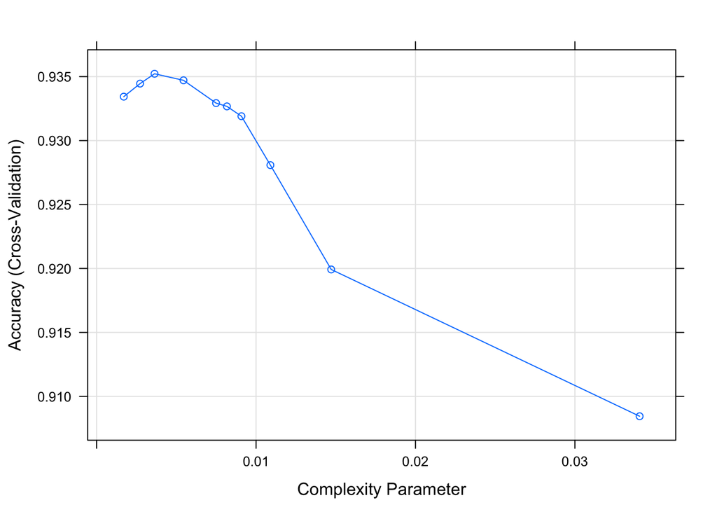

```r
plot(mod_trees)
```

```r
mod_trees$bestTune
```

```
##            cp
## 3 0.003633061
```

We have 10 different trees, and one with the cp of 0.00363 is our best tree with the highest accuracy of 93.5%. You can use `plot` and `text` to plot out the tree for detail.

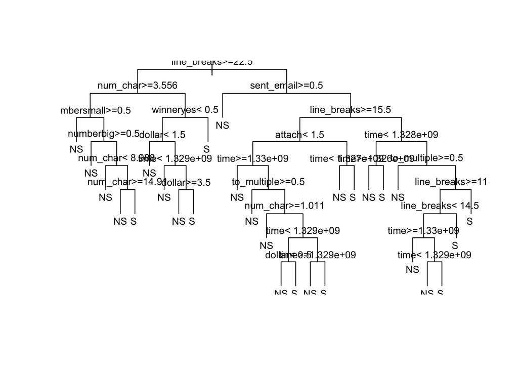

```r
plot(mod_trees$finalModel, uniform = TRUE)
text(mod_trees$finalModel, cex = .8)
```

# Exercise

### Exercise 1.

Use these five variables (`num_char`, `image`, `attach`, `dollar`, `re_subj`) to build a spam filter. Use `train()` to build a logistic regression model with 20-fold cross validation. What is the model accuracy?

```r
# write your code below this comment line
```

### Exercise 2.

Use the same variables to build a decision tree. Do 20-fold cross validation. What is the accuracy of the best model?

```r
# write your code below this comment line
```

### Exercise 3.

Plot the tree using `plot()` and `text()` function. What is the first condition appearing at the root? What does it mean?

### Exercise 4.

Change `tuneLength` option to grow 20 trees, and plot them out to see how the accuracy changes along with complexity parameter. Did you find a better model?